# 决策树(Decision Tree)与随机森林(Random Forests)

作者：欧新宇（Xinyu OU）

本文档所展示的测试结果，均运行于：Intel Core i7-7700K CPU 4.2GHz

### 目录

- 1.决策树
  - 1.1决策树的基本原理
  - 1.2决策树的构建
- 2.随机森林
- 3.实例分析——基于Adult数据集的相亲问题

## 1. 决策树

### 1.1决策树的基本原理

**决策树(Decision Tree)** 是一种基本的分类和回归算法（本课程仅讨论决策树在分类中的应用）。决策树模型呈树形结构，在分类问题中，依据样本的特征对实例进行分类，是一种典型的if-then/else-then推导规则，从数学原理上理解，它也可以被认为是定义在特征空间与类别空间上的条件概率分布。

- 学习时: 利用训练数据，根据损失函数最小化的原则建立决策树模型;
- 预测时: 对新的数据，利用决策树模型进行分类。

决策树学习通常包括3个步骤：特征选择、决策树的生成和决策树的修剪。

下面给出一个利用决策树进行判定的图例，要求：根据一系列的属性特征输出特定的人物：

[figure not shown]

### 1.2决策树的构建

#### 1. 载入数据库并进行数据预处理

以wine酒数据集为例，构建一个决策树模型

```python
# 导入numpy计算库
import numpy as np

# 导入画图工具
import matplotlib.pyplot as plt
from matplotlib.colors import ListedColormap

# 导入tree树模型和数据集加载工具
from sklearn import tree
from sklearn import datasets
# 导入数据拆分工具
from sklearn.model_selection import train_test_split
wine = datasets.load_wine()

# 设置X, y的值。此处为了便于可视化，仅选取前两个特征
X = wine.data[:, :2]
#X = wine.data
y = wine.target
# 将数据集拆分为训练集和测试集
X_train, X_test, y_train, y_test = train_test_split(X, y)
```

#### 2. 配置决策树，并拟合训练集

```python
# 设置决策树的分类器的最大深度为 1
clf = tree.DecisionTreeClassifier(max_depth = 1)
# 拟合训练数据集
clf.fit(X_train, y_train)
```

```
DecisionTreeClassifier(class_weight=None, criterion='gini', max_depth=1,
                       max_features=None, max_leaf_nodes=None,
                       min_impurity_decrease=0.0, min_impurity_split=None,
                       min_samples_leaf=1, min_samples_split=2,
                       min_weight_fraction_leaf=0.0, presort=False,
                       random_state=None, splitter='best')
```

#### 3. 可视化分类器结果

```python
# 定义图像中分区的颜色和散点的颜色
cmap_light = ListedColormap(['#FFAAAA', '#AAFFAA', '#AAAAFF'])
cmap_bold = ListedColormap(['#FF0000', '#00FF00', '#0000FF'])

# 分别用样本的两个特征值创建图像的横轴和纵轴
x_min, x_max = X_train[:, 0].min() - 1, X_train[:, 0].max() + 1
y_min, y_max = X_train[:, 1].min() - 1, X_train[:, 1].max() + 1
# 设置特征轴的尺度的粒度
xx, yy = np.meshgrid(np.arange(x_min, x_max, 0.02), np.arange(y_min, y_max, 0.02))

Z = clf.predict(np.c_[xx.ravel(), yy.ravel()])

# 给每个分类中的样本分配不同的颜色
Z = Z.reshape(xx.shape)
plt.figure(dpi = 100)
plt.rcParams['font.sans-serif'] = [u'Microsoft YaHei']
plt.pcolormesh(xx, yy, Z, cmap = cmap_light)


# 用散点把样本表示出来
plt.scatter(X[:, 0], X[:, 1], c = y, cmap = cmap_bold, edgecolor = 'k', s = 20)
plt.xlim(xx.min(), xx.max())
plt.ylim(yy.min(), yy.max())
plt.title("分类器: 决策树(max_depth = 1)")

plt.show()
```

[output not shown]

【知识点】[ravel()函数、flatten()函数和squeeze()函数](functions/numpy.ravel_flatten_squeeze.ipynb)

#### 4. 对比不同深度决策树的分类性能

- 深度max_depth = 3 时

```python
import matplotlib.pyplot as plt3

# 设置决策树的分类器的最大深度，并拟合训练集
clf3 = tree.DecisionTreeClassifier(max_depth = 3)
clf3.fit(X_train, y_train)
```

```
DecisionTreeClassifier(class_weight=None, criterion='gini', max_depth=3,
                       max_features=None, max_leaf_nodes=None,
                       min_impurity_decrease=0.0, min_impurity_split=None,
                       min_samples_leaf=1, min_samples_split=2,
                       min_weight_fraction_leaf=0.0, presort=False,
                       random_state=None, splitter='best')
```

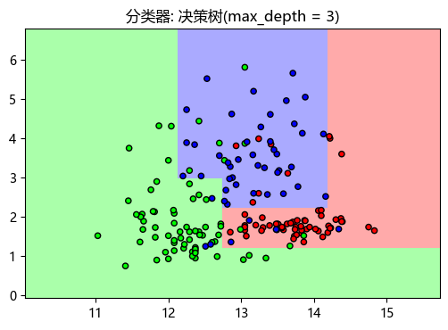

```python
Z3 = clf3.predict(np.c_[xx.ravel(), yy.ravel()])

# 给每个分类中的样本分配不同的颜色
Z3 = Z3.reshape(xx.shape)
plt3.figure(dpi = 100)
plt.rcParams['font.sans-serif'] = [u'Microsoft YaHei']
plt3.pcolormesh(xx, yy, Z3, cmap = cmap_light)

# 用散点把样本表示出来
plt3.scatter(X[:, 0], X[:, 1], c = y, cmap = cmap_bold, edgecolor = 'k', s = 20)
plt3.xlim(xx.min(), xx.max())
plt3.ylim(yy.min(), yy.max())
plt3.title("分类器: 决策树(max_depth = 3)")

plt3.show()
```

- 深度max_depth = 5 时

```python
import matplotlib.pyplot as plt5

# 设置决策树的分类器的最大深度，并拟合训练集
clf5 = tree.DecisionTreeClassifier(max_depth = 5)
clf5.fit(X_train, y_train)
```

```
DecisionTreeClassifier(class_weight=None, criterion='gini', max_depth=5,
                       max_features=None, max_leaf_nodes=None,
                       min_impurity_decrease=0.0, min_impurity_split=None,
                       min_samples_leaf=1, min_samples_split=2,
                       min_weight_fraction_leaf=0.0, presort=False,
                       random_state=None, splitter='best')
```

```python
Z5 = clf5.predict(np.c_[xx.ravel(), yy.ravel()])

# 给每个分类中的样本分配不同的颜色
Z5 = Z5.reshape(xx.shape)
plt5.figure(dpi = 100)
plt.rcParams['font.sans-serif'] = [u'Microsoft YaHei']
plt5.pcolormesh(xx, yy, Z5, cmap = cmap_light)

# 用散点把样本表示出来
plt5.scatter(X[:, 0], X[:, 1], c = y, cmap = cmap_bold, edgecolor = 'k', s = 20)
plt5.xlim(xx.min(), xx.max())
plt5.ylim(yy.min(), yy.max())
plt5.title("分类器: 决策树(max_depth = 5)")

plt5.show()
```

[output not shown]

#### 5. 对模型进行评估

分别评估三个模型在训练集、测试集上的准确率

```python
# 输出模型评分，即正确率
score_train = clf.score(X_train, y_train)
score3_train = clf3.score(X_train, y_train)
score5_train = clf5.score(X_train, y_train)
score_test = clf.score(X_test, y_test)
score3_test = clf3.score(X_test, y_test)
score5_test = clf5.score(X_test, y_test)

print("模型一(树深 = 1)：训练集准确率：{0:.3f}，测试集准确率：{1:.3f}".format(score_train, score_test))
print("模型二(树深 = 3)：训练集准确率：{0:.3f}，测试集准确率：{1:.3f}".format(score3_train, score3_test))
print("模型三(树深 = 5)：训练集准确率：{0:.3f}，测试集准确率：{1:.3f}".format(score5_train, score5_test))
```

[output not shown]

由结果可以得到以下结论：

1. 随着决策树的深度增加，模型的性能得到了一定的提升（*在一定范围内*）;
2. 深度增加到5时，模型出现了过拟合现象。即：训练集性能持续提高，测试集性能出现了降低。

下面请大家尝试，在Wine酒数据集上使用**决策树**对所有特征进行建模，并给出树深分别为{1, 3, 5}时的模型准确率。

### 1.3 决策树的优缺点

- 优点：计算复杂度低，分类速度快，模型易于理解、可读性高，对中间值的缺失不敏感
- 缺点：可能会产生过度匹配问题
- 适用数据类型：数值型和标称型

### 1.4 决策树的工作过程的可视化

*(不要求掌握该方法，只需要能理解即可)*

Graphviz (Graph Visualization Software) 是一个由AT&T实验室启动的开源工具包，可以用于绘制各种流程图和结构图。它依赖于DOT描述语言，DOT是一种图形描述语言，具有简单易学的特点。

对于程序员来说，关于Graphviz有一句很著名的话：So in short, if you are a programmer, it is born for you。

- 安装graphviz
1. 官网下载 [graphviz](https://graphviz.gitlab.io/_pages/Download/Download_windows.html), 并进行安装
2. 添加系统变量，将"./Graphviz2.38" 和 "./Graphviz2.38/bin"添加到环境变量；将"./Graphviz2.38/bin/dot.exe"添加到系统变量。
3. pip install graphviz 或 conda install graphviz
- 绘制流程图

```python
# 载入graphviz绘图工具包
import graphviz

# 导入决策树中输出graphiviz的接口
from sklearn.tree import export_graphviz

import os
filePath = os.path.join(os.getcwd() + '\\tmp\\')
fileName = os.path.join(filePath + 'Wine.dot')

#选择分类模型
export_graphviz(clf3, out_file = fileName, \
                class_names = wine.target_names, \
                feature_names = wine.feature_names[:2], \
                impurity = False, filled = True)
# 打开dot文件
with open(fileName) as f:
    dot_graph = f.read()

# 显示dot文件中的图形
graphviz.Source(dot_graph)
```

[figure not shown]

## 2.随机森林

决策树是一种比较简单的算法，但是很容易出现过拟合问题*（前面我们已经看到了这个现象）*，一个比较好的解决办法是，将更多的树扩展成森林————随机森林。

随机森林是一种有监督学习算法，它是以决策树为**基学习器**的集成学习算法。随机森林非常简单，易于实现，计算开销也很小，但是它在分类和回归上表现出非常惊人的性能，因此，随机森林被誉为“代表集成学习技术水平的方法”。

**【知识点】**集成学习（ensemble learning）: 集成学习是一种非常有效的学习方法，它致力于整合多个弱分类器为强分类器，从而实现整体性能的提升。最常见的算法有：bootstrape, boosting和bagging等。  
中国自古就有：三个臭皮匠顶个诸葛亮，一箭易折十箭难折，千里之堤溃于蚁穴。有兴趣的同学可以百度一下*集成学习*。

### 2.1 随机森林的基本概念

在机器学习中，**随机森林**是一个包含多个决策树的分类器，其输出的类别是由每棵树的输出进行联合判决。随机森林最初是由Leo Breiman和Adele Cutler提出，并以"Random Forests"作为商标，而该术语则是由贝尔实验室的Tin Kam Ho所提出的随机决策森林（random decision forests）而来。

以下给出，随机森林的算法过程：

```
1. 假设用 N 来表示训练样本的个数，M 表示特征的数目;
2. 输入特征数目 m，用于确定决策树上一个节点的决策结果；其中 m 应远小于 M;
3. 从 N 个训练样本中以（放回）抽样的方式，取样 N 次，形成一个训练集（即 bootstrap取样），并用未抽到的用例（样本）作预测，评估其误差；
4. 对于每一个节点，随机选择 m个特征，决策树上每个节点的决定都是基于这些特征确定的。根据这 m个特征，计算其最佳的分裂方式。
5. 每棵树都会完整成长而不会剪枝，这有可能在建完一棵正常树状分类器后会被采用。
```

[figure not shown]

### 2.2 随机森林的构建

#### 1. 载入Wine酒数据集并进行预处理

```python
from sklearn import datasets
from sklearn.model_selection import train_test_split

# 导入随机森林模型
from sklearn.ensemble import RandomForestClassifier

wine = datasets.load_wine()
X = wine.data[:, :2] # 为便于可视化仍然仅使用前两个特征
y = wine.target
X_train, X_test, y_train, y_test = train_test_split(X, y)
```

#### 2. 模型训练

```python
# 设定随机森林中树的数量，此处 = 6
forest = RandomForestClassifier(n_estimators = 6, random_state = 3, n_jobs = -1)
forest.fit(X_train, y_train)
```

```
RandomForestClassifier(bootstrap=True, class_weight=None, criterion='gini',
                       max_depth=None, max_features='auto', max_leaf_nodes=None,
                       min_impurity_decrease=0.0, min_impurity_split=None,
                       min_samples_leaf=1, min_samples_split=2,
                       min_weight_fraction_leaf=0.0, n_estimators=6, n_jobs=-1,
                       oob_score=False, random_state=3, verbose=0,
                       warm_start=False)
```

**关于随机森林参数的一些解释：**

- **bootstrap(True,False)**: 该参数用于设定是否启用bootstrap算法，即“有放回抽样”，准确地说叫“重抽样”。它允许每次生成的数据集都从一个统一的数据集中进行采样，这样一方面可以保证总样本数不变，另一方面也确保了采样的随机性。Bootstrap是现代统计学较为流行的一种统计方法，在小样本数据集中使用效果很好，通过方差的估计可以构造置信区间等，其运用范围得到进一步延伸。同时，对于未知样本分布的数据中，bootstrap也是最有用的，它可以用来估计真实的分布。
- **class_weight**: 指定样本各类别的的权重，主要是为了防止训练集某些类别的样本过多，导致训练的决策树过于偏向这些类别。其中最严重的现象之一就是"`长尾效应`"。典型值为“balanced”和“None”，前者算法会自己计算权重，样本量少的类别所对应的样本权重会高；后者，则使用等权重。当数据集样本类别分布没有明显偏向时，可以不管这个参数，保持默认的"None"。
- **max_features**: 该参数用于控制特征最大数量，典型值较多，包括int, $Log_2 N$，$sqrt{(N)}$, 浮点百分比等。当特征数较少（<50）可以不考虑该参数。
- **max_leaf_nodes(int, None)**: 强制剪枝参数，用于设置最大的叶子节点数，默认值为None，表示不限制叶子节点数。该参数通过强制剪枝实现生成的森林具有独特性，以实现样本预测的多样性。设置合理的max_leaf_nodes可以有效地改进过拟合和欠拟合问题。如果特征不多，可以不考虑该值；当特征较多时，通过限制叶子数可以获得最优森林，一般可以通过交叉验证来选择该参数的最优值。同样，当特征数较多的时候(例如>200)，可以考虑设置该参数。
- **n_estimators**(int): 这是一个非常重要的**参数**。用于设置随机森林中决策树的数量。对于回归分析，随机森林会把所有决策树预测的值取平均数进行输出；对于分类，随机森林会通过“投票”（求每棵树的概率的平均值）来预测样本的类别。
- **n_jobs(int, -1)**: 用于设置并行处理的CPU核心数，典型值为int型，表示使用多少个核心，当n_jobs = -1时，表示使用全部核心。在进行较大数据集的建模时，这将大幅提高训练的速度。不幸的是，scikit-learn工具包不支持GPU并行运算，只支持CPU的多核心并行。
- **random_state**: 该参数和其他算法中的含义一样，用于控制随机种子，以产生固化不变的"随机值"。

#### 3. 模型评估

```python
score_train = forest.score(X_train, y_train)
score_test = forest.score(X_test, y_test)

print("随机森林：\n 训练集准确率：{0:.3f}，测试集准确率：{1:.3f}".format(score_train, score_test))
```

[output not shown]

#### 4. 可视化分类结果

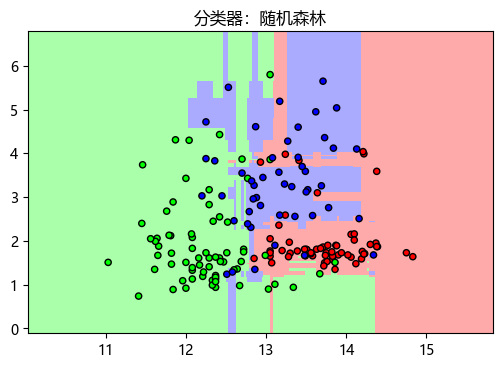

```python
# 定义图像中分区的颜色和散点的颜色
cmap_light = ListedColormap(['#FFAAAA', '#AAFFAA', '#AAAAFF'])
cmap_bold = ListedColormap(['#FF0000', '#00FF00', '#0000FF'])

# 分别用样本的两个特征值创建图像的横轴和纵轴
x_min, x_max = X_train[:, 0].min() - 1, X_train[:, 0].max() + 1
y_min, y_max = X_train[:, 1].min() - 1, X_train[:, 1].max() + 1
# 设置特征轴的尺度的粒度
xx, yy = np.meshgrid(np.arange(x_min, x_max, 0.02), np.arange(y_min, y_max, 0.02))

Z = forest.predict(np.c_[xx.ravel(), yy.ravel()])

# 给每个分类中的样本分配不同的颜色
Z = Z.reshape(xx.shape)
plt.figure(dpi = 100)
plt.rcParams['font.sans-serif'] = [u'Microsoft YaHei']
plt.pcolormesh(xx, yy, Z, cmap = cmap_light)

# 用散点把样本表示出来
plt.scatter(X[:, 0], X[:, 1], c = y, cmap = cmap_bold, edgecolor = 'k', s = 20)
plt.xlim(xx.min(), xx.max())
plt.ylim(yy.min(), yy.max())
plt.title("分类器：随机森林")

plt.show()
```

从结果看，随机森林获得的结果要更加细腻。有兴趣的同学，可以尝试调整一下参数n_estimator和random_state，看看是否能获得更好的预测结果。

### 2.3 随机森林的优缺点

- 优点
  - 由于采用了集成算法，本身精度比大多数单个算法要好，所以准确性高
  - 在测试集上表现良好，由于两个随机性的引入，使得随机森林不容易陷入过拟合（样本随机，特征随机）
  - 在工业上，由于两个随机性的引入，使得随机森林具有一定的抗噪声能力，对比其他算法具有一定优势
  - 由于树的组合，使得随机森林可以处理非线性数据，本身属于非线性分类（拟合）模型
  - 它能够处理很高维度（feature很多）的数据，并且不用做特征选择，对数据集的适应能力强：既能处理离散型数据，也能处理连续型数据，数据集无需规范化
  - 训练速度快，可以运用在大规模数据集上
  - 在训练过程中，能够检测到feature间的互相影响，且可以得出feature的重要性，具有一定参考意义
  - 由于每棵树可以独立、同时生成，容易做成并行化方法
  - 由于实现简单、精度高、抗过拟合能力强，当面对非线性数据时，适于作为基准模型（Baseline）
- 缺点
  - 当随机森林中的决策树个数很多时，训练时需要的空间和时间会比较大
  - 随机森林中还有许多不好解释的地方，有点算是黑盒模型
  - 在某些噪音比较大的样本集上，模型容易陷入过拟合

## 3.实例分析——基于Adult数据集的相亲问题

### 3.1 载入数据集

1. 下载数据集：

下载地址：http://archive.ics.uci.edu/ml/machine-learning-databases/adult

- adult.names 数据集的基本信息，文本文档（可改名）
- adult.data 训练集数据，下载后改名为：adult_train.csv
- adult.test 测试集数据，下载后改名为：adult_test.csv
1. 载入数据集

由于该数据集并没有在数据表中给出特征的描述，为了方便理解，我们需要手动添加特征的title（英文原版描述可以在adult.names文件中找到）。

```python
import pandas as pd
data = pd.read_csv('../Datasets/adult/adult_train.csv', header=None, index_col=False,
                  names=['年龄','单位性质','权重','学历','受教育时长',
                        '婚姻状况','职业','家庭情况','种族','性别',
                        '资产所得','资产损失','周工作时长','原籍',
                        '收入'])

# 使用display()函数显示部分数据，以供预览
# .head()方法实现只显示前 5 行
# display(data.head())

#为了方便展示，可以选取其中一部分特征（9个）进行显示
data_lite = data[['年龄','单位性质','学历','婚姻状况','种族','性别','周工作时长', '职业','收入']]
display(data_lite.head())
```

|  | 年龄 | 单位性质 | 学历 | 婚姻状况 | 种族 | 性别 | 周工作时长 | 职业 | 收入 |
| --- | --- | --- | --- | --- | --- | --- | --- | --- | --- |
| 0 | 39 | State-gov | Bachelors | Never-married | White | Male | 40 | Adm-clerical | <=50K |
| 1 | 50 | Self-emp-not-inc | Bachelors | Married-civ-spouse | White | Male | 13 | Exec-managerial | <=50K |
| 2 | 38 | Private | HS-grad | Divorced | White | Male | 40 | Handlers-cleaners | <=50K |
| 3 | 53 | Private | 11th | Married-civ-spouse | Black | Male | 40 | Handlers-cleaners | <=50K |
| 4 | 28 | Private | Bachelors | Married-civ-spouse | Black | Female | 40 | Prof-specialty | <=50K |

### 3.2 数据预处理

从原始数据可以看到绝大多数特征都是字符串形式，这是无法进行使用和分析的。我们有两种方法对数据进行预处理：

1. 将特征的每种取值都抽象成一种，并用布尔类型进行表示。例如，特征"学历"改为多个特征，包括"学历_Bachelors","学历_Masters", "学历_Doctorate"，每个特征的分别用0和1来表示，是否满足该条件。该方法被称为"one-hot编码(独热编码)".
2. 将特征的每种取值赋一个值。例如，特征"学历"将包含多个值，0表示Bachelors, 1表示Masters, 2表示Doctorate

此处，为了简便，我门将采用第一种(one-hot)方法，并使用pandas数据集的get_dummies()方法来实现。该方法为现有数据特征添加虚拟变量，将一个$n$类特征变量扩展为$n$个one-hot特征变量。

```python
data_dummies = pd.get_dummies(data_lite)
print('样本原始特征:\n',list(data_lite.columns),'\n')
print('虚拟变量特征:\n',list(data_dummies.columns))
```

```
样本原始特征:
 ['年龄', '单位性质', '学历', '婚姻状况', '种族', '性别', '周工作时长', '职业', '收入']

虚拟变量特征:
 ['年龄', '周工作时长', '单位性质_ ?', '单位性质_ Federal-gov', '单位性质_ Local-gov', '单位性质_ Never-worked', '单位性质_ Private', '单位性质_ Self-emp-inc', '单位性质_ Self-emp-not-inc', '单位性质_ State-gov', '单位性质_ Without-pay', '学历_ 10th', '学历_ 11th', '学历_ 12th', '学历_ 1st-4th', '学历_ 5th-6th', '学历_ 7th-8th', '学历_ 9th', '学历_ Assoc-ac…
```

```python
display(data_dummies.head())
```

|  | 年龄 | 周工作时长 | 单位性质_ ? | 单位性质_ Federal-gov | 单位性质_ Local-gov | 单位性质_ Never-worked | 单位性质_ Private | 单位性质_ Self-emp-inc | 单位性质_ Self-emp-not-inc | 单位性质_ State-gov | ... | 职业_ Machine-op-inspct | 职业_ Other-service | 职业_ Priv-house-serv | 职业_ Prof-specialty | 职业_ Protective-serv | 职业_ Sales | 职业_ Tech-support | 职业_ Transport-moving | 收入_ <=50K | 收入_ >50K |
| --- | --- | --- | --- | --- | --- | --- | --- | --- | --- | --- | --- | --- | --- | --- | --- | --- | --- | --- | --- | --- | --- |
| 0 | 39 | 40 | 0 | 0 | 0 | 0 | 0 | 0 | 0 | 1 | ... | 0 | 0 | 0 | 0 | 0 | 0 | 0 | 0 | 1 | 0 |
| 1 | 50 | 13 | 0 | 0 | 0 | 0 | 0 | 0 | 1 | 0 | ... | 0 | 0 | 0 | 0 | 0 | 0 | 0 | 0 | 1 | 0 |
| 2 | 38 | 40 | 0 | 0 | 0 | 0 | 1 | 0 | 0 | 0 | ... | 0 | 0 | 0 | 0 | 0 | 0 | 0 | 0 | 1 | 0 |
| 3 | 53 | 40 | 0 | 0 | 0 | 0 | 1 | 0 | 0 | 0 | ... | 0 | 0 | 0 | 0 | 0 | 0 | 0 | 0 | 1 | 0 |
| 4 | 28 | 40 | 0 | 0 | 0 | 0 | 1 | 0 | 0 | 0 | ... | 0 | 0 | 0 | 1 | 0 | 0 | 0 | 0 | 1 | 0 |

5 rows × 58 columns

从上面的图表中可以看出，原来的 9 个特征已经被扩展为 58 个，原因就是get_dummies()函数将原来的多类特征进行了one-hot扩展。下面，我们将新的特征分配给特征向量X和分类标签y。

此处，我们将"收入"定义为标签 y，如果"收入_>50K"，则$y = 1$; 否则 $y = 0$。

```python
features = data_dummies.loc[:,'年龄':'职业_ Transport-moving']
X = features.values
y = data_dummies['收入_ >50K'].values
```

```python
print("特征X的形态:{0}, 标签y的形态:{1}".format(X.shape, y.shape))
```

```
特征X的形态:(32561, 56), 标签y的形态:(32561,)
```

【知识点】[pandas中的loc()函数和iloc()函数](functions/loc_iloc.ipynb)

从数据结果来看，获取到的特征 X，共有32561个样本，每个样本包含56种特征。

### 3.3 使用决策树建模并进行评分

```python
# 拆分数据集，并用训练数据拟合决策树模型
from sklearn.model_selection import train_test_split
from sklearn import tree

X_train,X_test,y_train,y_test = train_test_split(X, y, random_state=0)
dt = tree.DecisionTreeClassifier(max_depth = 5)
dt.fit(X_train,y_train)

print('模型得分:{:.2f}'.format(dt.score(X_test,y_test)))
```

```
模型得分:0.82
```

*值得注意的是，此处建模所用的**训练集**和**测试集**均是由原有的训练集进行拆分获得。*

### 3.4 利用给定的数据进行预测

给定一个新样本，我们用模型预测一下他的收入情况。

- 给定特征：年龄27，周工作时长35，单位性质为国家机关(单位性质 *State-gov = 1)，学历为博士(学历* Doctorate = 1)，性别男(性别 *Male = 1)，未婚(婚姻状况* Never-married = 1)，亚洲人(种族 *Other = 1)，职业是教授(职业* Prof-specialty = 1)；*其他特征值 = 0*
- 收入情况：如果收入>=50K，则标签= 1；如果收入<=50K, 则标签 = 0

```python
Mr_Right =[[27, 35, 0, 0, 0, 0, 0, 0, 0, 1,
            0, 0, 0, 0, 0, 0, 0, 0, 0, 0,
            0, 1, 0, 0, 0, 0, 0, 0, 0, 0,
            0, 1, 0, 0, 0, 0, 0, 1, 0, 0,
            1, 0, 0, 0, 0, 0, 0, 0, 0, 0,
            0, 1, 0, 0, 0, 0]]
```

```python
pred = dt.predict(Mr_Right)
if dt == 1:
    print("大胆去追求真爱吧，这哥们月薪过5万了！")
else:
    print("不用去了，不满足你的要求")
```

```
不用去了，不满足你的要求
```

值得注意的是，Adult虽然是真实数据集，但是其数据仅仅是美国的特定人群，因此输出结果仅供娱乐！**切勿当真！**

### 3.5 更完整的建模和预测

在上面的例子中，我们对数据集进行了一定的简化，下面我们将展现如何更完整地利用数据集并进行分析，具体改进包括：

- 同时使用原始的训练集(adult_train)和测试集(adult_test)
- 使用所有特征
- 同时使用决策树和随机森林算法进行建模

```python
import pandas as pd
train = pd.read_csv('../Datasets/adult/adult_train.csv', header=None, index_col=False,
                  names=['年龄','单位性质','权重','学历','受教育时长',
                        '婚姻状况','职业','家庭情况','种族','性别',
                        '资产所得','资产损失','周工作时长','原籍',
                        '收入'])

test = pd.read_csv('../Datasets/adult/adult_test.csv', header=None, index_col=False,
                  names=['年龄','单位性质','权重','学历','受教育时长',
                        '婚姻状况','职业','家庭情况','种族','性别',
                        '资产所得','资产损失','周工作时长','原籍',
                        '收入'])
test = test.loc[1:]

print("train: {}, test: {}".format(train.shape, test.shape))
```

```
train: (32561, 15), test: (16281, 15)
```

```python
train_dummies = pd.get_dummies(train)
test_dummies = pd.get_dummies(test)

print("train的形态为: {}, test的形态为: {}".format(train_dummies.shape, test_dummies.shape))
```

```
train的形态为: (32561, 110), test的形态为: (16281, 181)
```

从训练集和测试集的形态来看，它们具有不同的特征空间，因此无法用统一的标准进行衡量，因此，我们需要先将两个数据集进行合并，扩展特征后，再进行拆分。

此处，我们可以使用pandas.concat()函数实现合并。

```python
data = pd.concat([train,test],ignore_index=True, axis=0) # axis = 0表示在纵轴上进行合并； axis = 1 表示在横轴上进行合并。
data_dummies = pd.get_dummies(data)

print("data_dumies的形态为: {}".format(data_dummies.shape))
```

```
data_dumies的形态为: (48842, 257)
```

在进行特征one-hot扩展之后，我们可以再次对样本进行拆分，拆分时可以使用原始样本的大小作为索引。

```python
train_dummies = data_dummies.loc[0:train.shape[0] - 1]
test_dummies = data_dummies.loc[train.shape[0]:]

print("train的形态为: {}, test的形态为: {}".format(train_dummies.shape, test_dummies.shape))
```

```
train的形态为: (32561, 257), test的形态为: (16281, 257)
```

此处，我们将除了收入以外的所有特征作为样本的特征，以"收入_ >50K"作为判别目标。

即，我们的目标是通过对所有特征的分析来获取收入的预测。

```python
X_train = train_dummies.loc[:, '权重':'原籍_ Yugoslavia'].values
y_train = train_dummies['收入_ >50K'].values

X_test = test_dummies.loc[:, '权重':'原籍_ Yugoslavia'].values
y_test = test_dummies['收入_ >50K'].values
```

- 使用决策树和随机森林进行建模

```python
from sklearn import tree
from sklearn.ensemble import RandomForestClassifier

dt = tree.DecisionTreeClassifier(max_depth = 5)
dt.fit(X_train, y_train)

forest = RandomForestClassifier(n_estimators = 6, random_state = 3, n_jobs = -1)
forest.fit(X_train, y_train)

print('决策树模型: 训练集得分: {0:.3f}，测试集得分: {1:.3f}'.format(dt.score(X_train,y_train), dt.score(X_test,y_test)))
print('随机森林模型: 训练集得分: {0:.3f}，测试集得分: {1:.3f}'.format(forest.score(X_train,y_train), forest.score(X_test,y_test)))
```

```
决策树模型: 训练集得分: 0.853，测试集得分: 0.841
随机森林模型: 训练集得分: 0.976，测试集得分: 0.832
```

### 3.6 超参数搜索

从上面的结果看，随机森林有较严重的过拟合问题，理论上有一定的改进空间，下面我们尝试对**决策树**和**随机森林**都进行超参数搜索，看看是否能进一步提高它们的性能。

- 对于决策树，我们遍历树的深度，设 max_depth = [1 : 100]
- 对于随机森林，我们遍历森林的规模，设 n_estimators = [1 : 100]

然后，我们将不同参数下的评分输出成图。

```python
import numpy as np

n = 100
scores = np.zeros([4, n]) #第1-4列分别为：score_train_dt,score_test_dt,score_train_rf,score_test_rf
num = np.arange(0, n)


for i in num:
    n = i + 1

    # 利用当行刷新方法显示正在计算的模型
    print("\r 正在计算第{}/{}个模型，请稍等...".format(n, num.shape[0]), end="")

    dt = tree.DecisionTreeClassifier(max_depth = n)
    dt.fit(X_train, y_train)

    rf = RandomForestClassifier(n_estimators = n, random_state = 3, n_jobs = -1)
    rf.fit(X_train, y_train)

    scores[0, i] = dt.score(X_train, y_train)
    scores[1, i] = dt.score(X_test, y_test)
    scores[2, i] = rf.score(X_train, y_train)
    scores[3, i] = rf.score(X_test, y_test)

    if i == num.shape[0] - 1:
        print("计算完毕！")
```

```
 正在计算第100/100个模型，请稍等...计算完毕！
```

利用输出的分数矩阵绘制"参数敏感"性能曲线图。参数敏感曲线通常用来进行参数选择，当参数稳定且达到峰值的时候就是参数的最优值。

[figure not shown]

```python
import matplotlib.pyplot as plt

plt.figure(dpi=120)
plt.plot(num, scores[0,:], label="DecisionTree_Train")
plt.plot(num, scores[1,:], label="DecisionTree_Test")
plt.plot(num, scores[2,:], label="ForestClassifier_Train")
plt.plot(num, scores[3,:], label="ForestClassifier_Test")

plt.legend()
plt.show()
```

从结果来看，决策树和随机森林都出现了过拟合的现象，并且在训练集上的结果基本一致，这说明训练样本过于简单，不具备多样性。

在测试集上，随机森林比决策树要更好一些。有趣的是，决策树的性能持续下降最终收敛，而随机森林的性能开始振荡严重，但最终也收敛了。

但这不是说决策树在深度较浅的时候就一定好，因为性能的衡量不仅仅包括score，还包括召回率、ROC、AUC曲线等。

此处主要是用来演示（让大家学会）如何使用性能曲线来选择超参数。